# Tasks and duties of public health graduates

We are looking to explore the tasks and duties that public health graduates report they use.

```python
# Ignore Warnings
import warnings
warnings.filterwarnings('ignore')
```

## Load the data, deal with duplicates, merge

What we know about the data files

- Universities Australia Data Final 2016.csv is completely unique, they were all collected 20/12/2016
- Universities Australia Data Final 2017.csv is completely unique, they were all collected 27/9/2017
- Universities Australia Data Final 2016 2017.csv is a subset of 2016_2018_GOS_UA_Data.csv
- 2016_2018_GOS_1055_UWA_Data.csv contains no unique data (i.e. all the rows are captured elsewhere)

Therefore, the combination of these data files will make up our final dataset. We will merge these files with the tasks and duties files we have obtained separately.

Loading in the modules we need

```python
import numpy as np
import pandas as pd
import glob
```

Finding the data files which we need to concatenate, and separating this from the data file we will merge

```python
ags_files = glob.glob('*.csv')
ags_data = ags_files[:-1] #The three data files minus the duties
duties_file = ags_files[-1] #The duties file, which we will merge later
```

Create the dataframe from the data files not including the tasks and duties, set the index to the GOSID variable

```python
df = pd.concat([pd.read_csv(x, encoding='latin1', index_col='GOSID') for x in ags_data])
df.head()
```

| GOSID | ACTLHRS | ACTLHRSM | AGE | ANALYS45 | ANALYSIS | ANZSCO | ANZSIC | AREA | AREA45 | ATSI | ... | WORKED | WWOPAY | YEAR | YEARARRV | YEARCOMM | first_ASGS_metro | first_ASGS_regional | first_ASGS_remote | first_SA1 | first_SES_SA1 |
| --- | --- | --- | --- | --- | --- | --- | --- | --- | --- | --- | --- | --- | --- | --- | --- | --- | --- | --- | --- | --- | --- |
| 1610191000001 | 50.0 | 995.0 | NaN | 1.0 | 1 | 241213 | 8021 | 13.0 | 25.0 | NaN | ... | 1 | 95 | 2015 | NaN | NaN | NaN | NaN | NaN | NaN | NaN |
| 1610191000002 | 38.0 | 995.0 | NaN | 1.0 | 1 | 511111 | 7510 | 16.0 | 36.0 | NaN | ... | 1 | 95 | 2015 | NaN | NaN | NaN | NaN | NaN | NaN | NaN |
| 1610191000003 | 55.0 | 995.0 | NaN | 1.0 | 1 | 241213 | 8220 | 13.0 | 25.0 | NaN | ... | 1 | 95 | 2015 | NaN | NaN | NaN | NaN | NaN | NaN | NaN |
| 1610191000004 | 40.0 | 995.0 | NaN | 1.0 | 1 | 242111 | 8102 | 2.0 | 5.0 | NaN | ... | 1 | 95 | 2015 | NaN | NaN | NaN | NaN | NaN | NaN | NaN |
| 1610191000005 | 40.0 | 995.0 | NaN | 1.0 | 1 | 254421 | 8401 | 6.0 | 16.0 | NaN | ... | 1 | 95 | 2015 | NaN | NaN | NaN | NaN | NaN | NaN | NaN |

5 rows × 435 columns

Create the dataframe from the tasks and duties datafile, set the index to the GOSID variable

```python
duties_df = pd.read_csv(duties_file, encoding='latin1', index_col='GOSID')
duties_df.head()
```

| GOSID | YEAR | VDUTIES |
| --- | --- | --- |
| 1610193000003 | 2016 | Teaching Primary School |
| 1610193000017 | 2016 | program and contract management |
| 1610193000044 | 2016 | Plan and implement the Australian Curriculum a... |
| 1610193000048 | 2016 | Teaching and Researching |
| 1610193000060 | 2016 | Clinical nurse consultant |

In the duties_df dataframe, there are duplicate IDs. However, we verify below that all duplicate IDs also have the same text, it is not a case of different entries being given for the same ID.

```python
duties_df.index.duplicated().sum()

a = len(duties_df[(duties_df.index.duplicated(keep=False)) & (duties_df.duplicated(subset='VDUTIES', keep=False))])
b = len(duties_df[duties_df.index.duplicated(keep=False)])
a == b
```

```
True
```

Therefore, we can drop duplicates and NaN without a worry, and merge the unique entries.

```python
print("Length of duties_df before dropping NaN, before dropping duplicates: {}".format(len(duties_df)))
duties_df = duties_df.dropna()
print("Length of duties_df after dropping NaN, before dropping duplicates: {}".format(len(duties_df)))
duties_df = duties_df[~duties_df.index.duplicated(keep='first')]
print("Length of duties_df after dropping NaN, after dropping duplicates: {}".format(len(duties_df)))
```

```
Length of duties_df before dropping NaN, before dropping duplicates: 326938
Length of duties_df after dropping NaN, before dropping duplicates: 230291
Length of duties_df after dropping NaN, after dropping duplicates: 229994
```

Here we merge the two dataframes:

- The original dataframe (df), which contains the three sets of AGS data
- The duties dataframe (duties_df), which contains the tasks and duties

The lengths of the pre-merged dataframe, and the post-merged dataframe should be the same, because we are merging into the dataframe, not adding new rows. We can see that this is correct.

```python
print("Length of df before merging: {}".format(len(df)))
df = df.merge(duties_df[['VDUTIES']], how='left', left_index=True, right_index=True)
print("Length of df after merging: {}".format(len(df)))
```

```
Length of df before merging: 544137
Length of df after merging: 544137
```

## Defining our cohort

We can define our cohort as the set of the following:

- Those who have most recently graduated from a Masters (Coursework)
- Those who have graduated in public health
- Those who have documented tasks and duties

This set can be found simply using the following codes for the relevant AGS variables:

```python
e461_codes = [
                61300, # Public Health
                61301, # Occupation Health and Safety (query this one?)
                61303, # Environmental Health
                61305, # Indigenous Health
                61307, # Health Promotion
                61309, # Community Health
                61311, # Epidemiology
                61399, # Public Health NEC
]


e310_codes = [
                #3,  #Masters (Research) <- We are not including this
                4, # Masters (Coursework)
]
```

Let's define our cohort using these parameters

```python
cohort = df[
            (df['E461'].isin(e461_codes)) & # Those who have graduated in public health
            (df['E310'].isin(e310_codes)) & # Those who have graduated from a Master's
            (~df['VDUTIES'].isnull())   # Those who have written about tasks and duties
]
```

We may choose to limit this later on, but for now, it's a wide selection of public health graduates

## Initial Data Exploration

```python
# Visualisation Libraries and A4 dimensions
import matplotlib.pyplot as plt
import seaborn as sns
a4_dims = (11.7, 8.27)
%matplotlib inline
```

What is the size of our cohort?

```python
print("The size of our cohort is: {}".format(len(cohort)))
```

```
The size of our cohort is: 2148
```

What proportion are male and female?

```python
# Gender as a percentage
cohort['E315'].value_counts(normalize = True) * 100
```

```
F    71.741155
M    28.212291
X     0.046555
Name: E315, dtype: float64
```

How old are our cohort?

- E314 - birth date
- E913 - age code

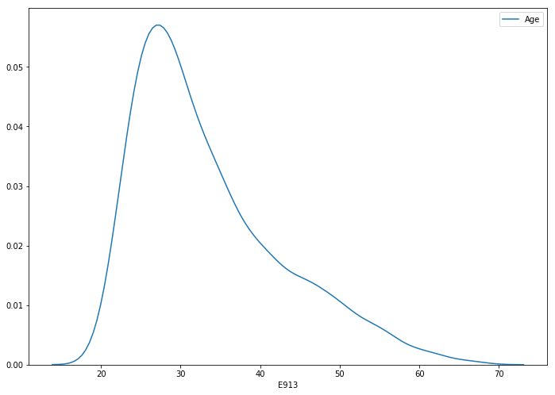

```python
# The distribution of ages of our cohort

fig, ax = plt.subplots(figsize=a4_dims)
sns.distplot(a=cohort['E913'], label="Age", hist=False)
plt.legend()
```

Where are our cohort from? What universities?

- E306, E306C - university / name
- E996 - State/Territory of institution code

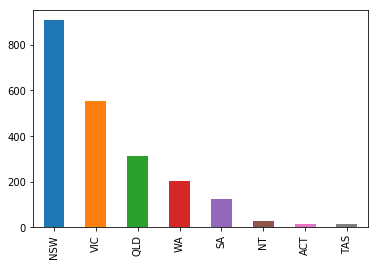

```python
# Bar Plot of our cohort's states/territories
cohort['E996'].value_counts().plot.bar()
```

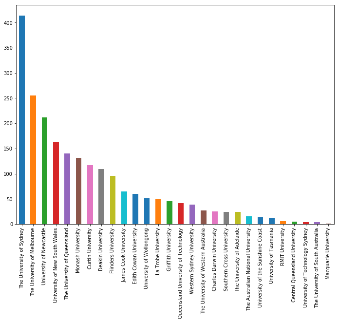

```python
# Bar plot of Universities where our cohort graduated
fig, ax = plt.subplots(figsize=a4_dims)
cohort['E306C'].value_counts().plot.bar()
```

What proportion are domestic and international? Where are international students from?

- E316 - Aboriginal, Torres Strait Islander
- E346 - Country of birth code
- E348 - Language spoken at home code
- E358 - Citizen / Resident indicator
- E490 - Student status code
- E941 - NESB indicator
- E942 - Citizenship indicator
- first_SA1 - socio-economic status

```python
# Percent Domestic and Overseas
cohort['E942'].value_counts(normalize=True) * 100
```

```
0.0    78.212291
1.0    21.787709
Name: E942, dtype: float64
```

```python
# Country of Origin if Overseas Student

"""
7103 - India
5202 - Indonesia
7105 - Nepal
9124 - Nigeria
6101 - China
7106 - Pakistan
1302 - Papua New Guinea
5105 - Vietnam
5102 - Cambodia
5101 - Burma
4213 - Saudi Arabia
"""

cohort[cohort['E942']==1]['E346'].value_counts()
```

```
7103.0    77
5202.0    55
7105.0    31
9124.0    26
6101.0    21
7106.0    21
1302.0    17
5105.0    15
5102.0    14
5101.0    14
4213.0    12
5203.0    12
8104.0    11
7101.0     8
8102.0     8
5204.0     7
9208.0     7
6105.0     6
6201.0     6
6102.0     5
5205.0     5
1502.0     4
9114.0     4
8205.0     4
9213.0     4
9231.0     3
9115.0     3
3308.0     3
4211.0     3
9232.0     3
          ..
9227.0     2
9217.0     1
2102.0     1
4207.0     1
8201.0     1
8407.0     1
9228.0     1
4102.0     1
8206.0     1
2100.0     1
1100.0     1
8204.0     1
4202.0     1
1402.0     1
9118.0     1
2401.0     1
5206.0     1
2308.0     1
4204.0     1
5104.0     1
9225.0     1
8213.0     1
6103.0     1
7102.0     1
2311.0     1
9103.0     1
8301.0     1
5201.0     1
9211.0     1
9127.0     1
Name: E346, Length: 74, dtype: int64
```

```python
# Indigenous Status - Value Counts

"""
2 = Non-indigenous
3 - Of Aboriginal origin but not Torres Strait Islander
9 - No information
"""

cohort['E316'].value_counts()
```

```
2.0    2113
9.0      19
3.0      16
Name: E316, dtype: int64
```

What proportion are taken from each survey year?

- COLYEAR

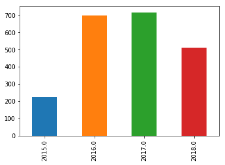

```python
# Collection Year - Bar plot
cohort['COLYEAR'].value_counts().sort_index(ascending=True).plot.bar()
```

What is the employment status of our cohort?

What sector / occupational group / industry group are our cohort employed in?

- WORKED - worked in the last week
- WWOPAY - worked without pay in the last week
- AWAYWORK - away from work
- LOOKFTWK - looking for fulltime work
- LOOKPTWK - looking for parttime work
- STARTWK - Able to start work
- WAITWORK - waiting to start work
- MORE1JOB - More than one job
- SELFEMP - Self employed
- PAYMENT - Form of payment
- PAYARRNG - Working or payment arrangement
- ACTLHRS - Actual hours worked
- ACTLHRSM - Actual hours worked in main job if multiple job
- USLHRS / USLHRSM - Usual hours worked
- PREFMHRS - prefer to work more hours
- PREFHRS - hours prefer to work if want more
- AVAILEMP - availability indicator
- GENEMP - employment indicator
- LFSTATUS - Labour force status
- LFCLASS - detailed labour force classification
- FFTJOB - first fulltime job
- FINDJOB - Where respondent found out about job
- ANZSCO - Occupation Code
- ANZSIC - Industry code
- SECTOR - Sector of employment
- INAUST - Working in Australia
- LOCATION - Location of workplace
- COUNTRY - country of workplace
- EMP12 - Employed for 12 months or more
- EMPTIME - Lenght of time with employer
- FURSTUD - Current futher study status
- FURFOE - Current further study - broad FOE
- FURLEV - Current further study - level of qualification
- FURINST - Further study institution code

```python
# Amount available to work
cohort['AVAILEMP'].value_counts(normalize = True) * 100
```

```
1    99.581006
0     0.418994
Name: AVAILEMP, dtype: float64
```

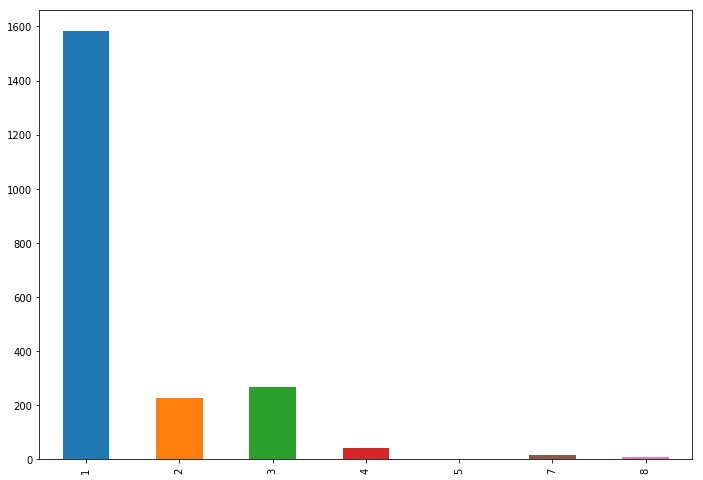

```python
# Detailed labour force classification
"""
1 - Employed full-time, usual or actual hours 35+
2 - Employed part-time, satisfied with hours
3 - Employed part-time, seeking more hours
4 - Employed part-time, unknown or missing more hours
5 - Unemployed, seeking full-time work
6 - Unemployed, seeking part-time work only
7 - Unemployed, waiting to start work
8 - Not in the labour force
"""

fig, ax = plt.subplots(figsize=a4_dims)
cohort['LFCLASS'].value_counts().sort_index(ascending=True).plot.bar()
```

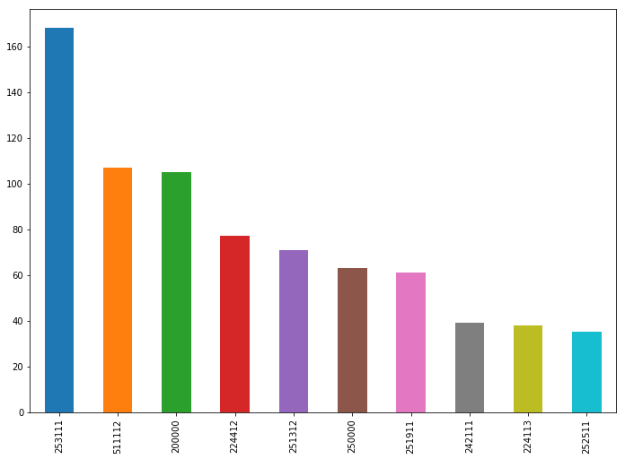

```python
# Top 10 ANZSCO - Bar Plot

"""
253111 General Medical Practitioner
511112 Program or Project Administrator
200000 Professionals nfd
224412 Policy Analyst
251312 Oc Health and Safety Advisor
250000 Health Professionals nfd
251911 Health Promotions Officer
242111 University Lecturer
224113 Statistician
252511 Physiotherapist
"""
fig, ax = plt.subplots(figsize=a4_dims)
cohort['ANZSCO'].value_counts()[:10].plot.bar()
```

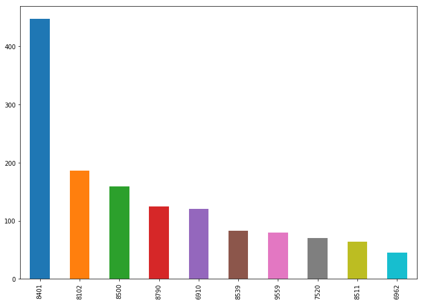

```python
# Top 10 ANZSIC - Bar Plot

"""
8401 - Hospitals Except Psychiatric Hospitals
8102 - Higher Education
8500 - (likely) Medical and Other Health Care Services NFD
8790 - Other Social Assistance Services
6910 - Scientific Research Services
8539 - Other Allied Health Services
9559 - Civic, Professional and Other Interest Group Services (Other interest group services nfp)
7520 - State Government Administration
8511 - General Practice Medical Services
6962 - Management Advice and Related Consulting Services
"""

fig, ax = plt.subplots(figsize=a4_dims)
cohort['ANZSIC'].value_counts()[:10].plot.bar()
```

What is the mean earnings of those employed?

- SALARYA - Annual salary for all jobs if working in Australia
- SALARYB - Annual salary for main job if working in Australia
- CURRENCY - Currency of salary if working overseas
- SALARY OS - Annual salary if working overseas
- TRIMSAL - indicates whether the salary is an outlier that should be excluded from salary reporting

[figure not shown]

```python
fig, ax = plt.subplots(figsize=a4_dims)
sns.distplot(a=cohort[(cohort['LFCLASS']==1) & (cohort['SALARYA']>0)]
             ['SALARYA'], hist=False)
```

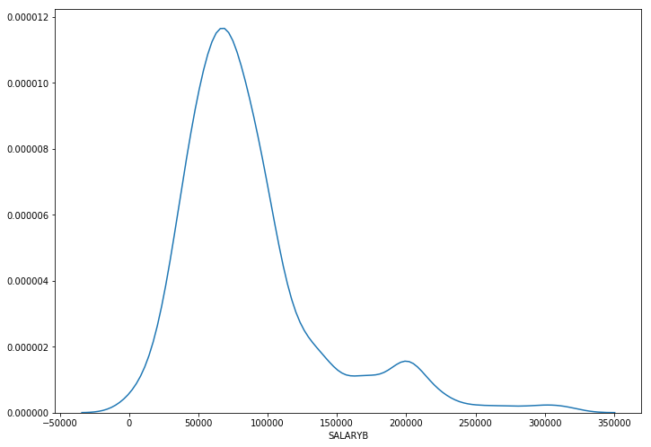

```python
fig, ax = plt.subplots(figsize=a4_dims)
sns.distplot(a=cohort[(cohort['LFCLASS']==1) & (cohort['SALARYB']>1)]
             ['SALARYB'], hist=False)
```

```python
print("Total salary, median   : {}".format(cohort[(cohort['LFCLASS']==1) & (cohort['SALARYA']>0)]['SALARYA'].median()))
print("Main job salary, median: {}".format(cohort[(cohort['LFCLASS']==1) & (cohort['SALARYB']>0)]['SALARYB'].median()))


print("Total salary, mean   : {}".format(cohort[(cohort['LFCLASS']==1) & (cohort['SALARYA']>0)]['SALARYA'].mean()))
print("Main job salary, mean: {}".format(cohort[(cohort['LFCLASS']==1) & (cohort['SALARYB']>0)]['SALARYB'].mean()))
```

```
Total salary, median   : 88000.0
Main job salary, median: 74229.5
Total salary, mean   : 97682.91941391942
Main job salary, mean: 87486.93055555556
```

Some mismatch questions

- RSOVRQ - Reason for working in a job that does not use skills and qualifications
- FORMREQ - Qualification required for current job
- QUALIMP - Importance of qualification for current job
- CRSPREP - Qualification preparedness
- SPOQ1 - Job requires less education than respondent has
- SPOQ2 - Respondent has more job skills than are required
- SPOQ3 - Someone with less educations than respondent could perform job well
- SPOQ4 - Respondents previous training is being fully utilised
- SPOQ5 - Resopndent has more knowledge than needed
- SPOQ6 - Respondents education level is above the level required
- SPOQ7 - Someone with less work experience than respondent could do just as well
- SPOQ8 - Respondnent has more abilities than needed
- SPOQSCL - Scale of percieved over qualification indicator

```python
# Perceived over-qualification indicator
"""
0 = No
1 = Yes
"""
cohort['SPOQSCL'].value_counts()
```

```
0      1261
100     815
999      57
995      15
Name: SPOQSCL, dtype: int64
```

```python
# When someone felt over-qualified, what was their occupation?
cohort[cohort['SPOQSCL']==100]['ANZSCO'].value_counts()[:10]
```

```
511112    37
621111    24
251312    23
253111    21
542114    18
250000    17
251911    17
531111    17
224412    17
200000    16
Name: ANZSCO, dtype: int64
```

```python
# When someone felt over-qualified, what was their industry?
cohort[cohort['SPOQSCL']==100]['ANZSIC'].value_counts()[:10]
```

```
8401    139
8790     57
8102     51
8500     49
8539     34
9559     29
8601     29
6910     27
7520     23
8511     17
Name: ANZSIC, dtype: int64
```

## Tasks and Duties

Let's look closer at the tasks and duties that our cohort perform. One initial way to look at this, is to look at the frequency of ngrams that our cohort report. A ngram is an amount of n-words, so this is in effect just counting the amount of times words or phrases come up.

Before doing this, we'll need to preprocess the text. Which includes doing the following things:

- Turning words into a list of tokens e.g. "Hello, I'm Rory" -> ['Hello', ',' , 'I'm', 'Rory]
- Changing all characters into lower-case characters e.g. "Hello" -> "hello"
- Stripping punctuation e.g. "Hello, I'm Rory" -> "Hello I'm Rory"
- Removing stop-words and very short words e.g. "This is a cat" -> "cat"

```python
import nltk
from nltk.tokenize import sent_tokenize, word_tokenize
from nltk.corpus import stopwords
from nltk import pos_tag
from nltk.stem import WordNetLemmatizer
from nltk.tokenize import sent_tokenize, word_tokenize
from nltk.corpus import stopwords
wnl = WordNetLemmatizer()
from sklearn.feature_extraction.text import CountVectorizer
from sklearn.feature_extraction.text import TfidfVectorizer

stop_json = ["a","a's", 'and',"able","about","above","according","accordingly","across","actually","after","afterwards","again","against","ain't","all","allow","allows","almost","alone","along","already","also","although","always","am","among","amongst","an","and","another","any","anybody","anyhow","anyone","anything","anyway","anyways","anywhere","apart","appear","appreciate","appropriate","are","aren't","around","as","aside","ask","asking","associated","at","available","away","awfully","b","be","became","because","become","becomes","becoming","been","before","beforehand","behind","being","believe","below","beside","besides","best","better","between","beyond","both","brief","but","by","c","c'mon","c's","came","can","can't","cannot","cant","cause","causes","certain","certainly","changes","clearly","co","com","come","comes","concerning","consequently","consider","considering","contain","containing","contains","corresponding","could","couldn't","course","currently","d","definitely","described","despite","did","didn't","different","do","does","doesn't","doing","don't","done","down","downwards","during","e","each","edu","eg","eight","either","else","elsewhere","enough","entirely","especially","et","etc","even","ever","every","everybody","everyone","everything","everywhere","ex","exactly","example","except","f","far","few","fifth","first","five","followed","following","follows","for","former","formerly","forth","four","from","further","furthermore","g","get","gets","getting","given","gives","go","goes","going","gone","got","gotten","greetings","h","had","hadn't","happens","hardly","has","hasn't","have","haven't","having","he","he's","hello","help","hence","her","here","here's","hereafter","hereby","herein","hereupon","hers","herself","hi","him","himself","his","hither","hopefully","how","howbeit","however","i","i'd","i'll","i'm","i've","ie","if","ignored","immediate","in","inasmuch","inc","indeed","indicate","indicated","indicates","inner","insofar","instead","into","inward","is","isn't","it","it'd","it'll","it's","its","itself","j","just","k","keep","keeps","kept","know","known","knows","l","last","lately","later","latter","latterly","least","less","lest","let","let's","like","liked","likely","little","look","looking","looks","ltd","m","mainly","many","may","maybe","me","mean","meanwhile","merely","might","more","moreover","most","mostly","much","must","my","myself","n","name","namely","nd","near","nearly","necessary","need","needs","neither","never","nevertheless","new","next","nine","no","nobody","non","none","noone","nor","normally","not","nothing","novel","now","nowhere","o","obviously","of","off","often","oh","ok","okay","old","on","once","one","ones","only","onto","or","other","others","otherwise","ought","our","ours","ourselves","out","outside","over","overall","own","p","particular","particularly","per","perhaps","placed","please","plus","possible","presumably","probably","provides","q","que","quite","qv","r","rather","rd","re","really","reasonably","regarding","regardless","regards","relatively","respectively","right","s","said","same","saw","say","saying","says","second","secondly","see","seeing","seem","seemed","seeming","seems","seen","self","selves","sensible","sent","serious","seriously","seven","several","shall","she","should","shouldn't","since","six","so","some","somebody","somehow","someone","something","sometime","sometimes","somewhat","somewhere","soon","sorry","specified","specify","specifying","still","sub","such","sup","sure","t","t's","take","taken","tell","tends","th","than","thank","thanks","thanx","that","that's","thats","the","their","theirs","them","themselves","then","thence","there","there's","thereafter","thereby","therefore","therein","theres","thereupon","these","they","they'd","they'll","they're","they've","think","third","this","thorough","thoroughly","those","though","three","through","throughout","thru","thus","to","together","too","took","toward","towards","tried","tries","truly","try","trying","twice","two","u","un","under","unfortunately","unless","unlikely","until","unto","up","upon","us","use","used","useful","uses","using","usually","uucp","v","value","various","very","via","viz","vs","w","want","wants","was","wasn't","way","we","we'd","we'll","we're","we've","welcome","well","went","were","weren't","what","what's","whatever","when","whence","whenever","where","where's","whereafter","whereas","whereby","wherein","whereupon","wherever","whether","which","while","whither","who","who's","whoever","whole","whom","whose","why","will","willing","wish","with","within","without","won't","wonder","would","wouldn't","x","y","yes","yet","you","you'd","you'll","you're","you've","your","yours","yourself","yourselves","z","zero"]
other_stops = ['or','include']
new_stop_words = list(set(stop_json + other_stops + stopwords.words('english')))

def penn2morphy(penntag):
    """ Converts Penn Treebank tags to WordNet. """
    morphy_tag = {'NN':'n', 'JJ':'a',
                  'VB':'v', 'RB':'r'}
    try:
        return morphy_tag[penntag[:2]]
    except:
        return 'n'

def preprocessing(text):
    # tokenize into words
    tokens = [word for sent in nltk.sent_tokenize(text) for word in nltk.word_tokenize(sent)]

    # lower capitalization
    tokens = [word.lower() for word in tokens]

    # remove words less than three letters
    tokens = [word for word in tokens if len(word) >= 3]

    # remove stop words
    #tokens = [word for word in tokens if word not in new_stop_words]

    # lemmatize
    tokens = [wnl.lemmatize(word,pos=penn2morphy(tag)) for word, tag in pos_tag(tokens)]
    preprocessed_text = ' '.join(tokens)

    return preprocessed_text
```

```python
cohort.loc[1710193000074]['VDUTIES']
```

```
'Providing anaesthesia care to patients undergoing elective and emergency surgery. Provide pre- and post-operative medical care to patients undergoing elective and emergency surgery.'
```

```python
cohort['VDUTIES'].dropna().apply(preprocessing).loc[1710193000074]
```

```
'provide anaesthesia care patient undergo elective and emergency surgery provide pre- and post-operative medical care patient undergo elective and emergency surgery'
```

We can see from about that our preprocessor is doing what we hoped it would do. Now, let's generate the top twenty words, and the top twenty phrases.

Below is the top twenty words used by our cohort.

```python
role_vect = CountVectorizer(ngram_range=(1,1), stop_words = new_stop_words, preprocessor = preprocessing)
role_matrix = role_vect.fit_transform(cohort['VDUTIES'].dropna())
cohort_words = pd.DataFrame(role_matrix.todense(), columns = role_vect.get_feature_names())
cohort_words.sum().sort_values(ascending=False)[:20]
```

```
health        451
management    396
patient       356
research      323
care          292
project       233
clinical      231
data          217
service       196
manage        183
work          179
program       164
staff         146
write         145
report        142
analysis      141
policy        141
provide       138
support       133
medical       122
dtype: int64
```

Below is the top twenty phrases (between 2 and 3 words) for our cohort

```python
role_vect = CountVectorizer(ngram_range=(2,3), stop_words = new_stop_words, preprocessor = preprocessing)
role_matrix = role_vect.fit_transform(cohort['VDUTIES'].dropna())
cohort_words = pd.DataFrame(role_matrix.todense(), columns = role_vect.get_feature_names())
cohort_words.sum().sort_values(ascending=False)[:20]
```

```
project management    65
patient care          60
data analysis         52
health promotion      47
clinical trial        38
report write          35
customer service      34
data collection       33
care patient          32
mental health         29
public health         29
research project      28
health safety         27
literature review     27
health care           24
health service        24
analyse data          23
write report          22
treat patient         20
case management       18
dtype: int64
```

```python
# Test - comparison between occupations
# Medical Practitioners

role_vect = CountVectorizer(ngram_range=(2,3), stop_words = new_stop_words, preprocessor = preprocessing)
role_matrix = role_vect.fit_transform(cohort[cohort['ANZSCO']==253111]['VDUTIES'].dropna())
cohort_words = pd.DataFrame(role_matrix.todense(), columns = role_vect.get_feature_names())
cohort_words.sum().sort_values(ascending=False)[:20]
```

```
patient care                   16
care patient                   16
health care                     7
management patient              7
clinical care                   7
management plan                 5
treat patient                   5
intensive care                  4
medical care                    4
patient hospital                4
patient consultation            4
inpatient outpatient            4
patient clinic                  4
clinical work                   4
clinical management patient     3
clinical management             3
patient review                  3
clinical duty                   3
primary care                    3
review patient                  3
dtype: int64
```

```python
# Test - comparison between occupations
# Statisticians

role_vect = CountVectorizer(ngram_range=(2,3), stop_words = new_stop_words, preprocessor = preprocessing)
role_matrix = role_vect.fit_transform(cohort[cohort['ANZSCO']==224113]['VDUTIES'].dropna())
cohort_words = pd.DataFrame(role_matrix.todense(), columns = role_vect.get_feature_names())
cohort_words.sum().sort_values(ascending=False)[:20]
```

```
statistical analysis            9
data analysis                   5
analyse data                    4
data management                 3
disease surveillance            3
disease outbreak                3
public health                   2
management analysis             2
infectious disease              2
analysis data                   2
data management analysis        2
exposure measure                1
epidemiological surveillance    1
elimination program             1
empirical evidence              1
empirical evidence present      1
entire country                  1
entire country page             1
feedback central regional       1
environmental health            1
dtype: int64
```

```python
# Test - comparison between Medical Practitioners and Project Administrators
# Project Administrators

role_vect = CountVectorizer(ngram_range=(2,3), stop_words = new_stop_words, preprocessor = preprocessing)
role_matrix = role_vect.fit_transform(cohort[cohort['ANZSCO']==511112]['VDUTIES'].dropna())
cohort_words = pd.DataFrame(role_matrix.todense(), columns = role_vect.get_feature_names())
cohort_words.sum().sort_values(ascending=False)[:20]
```

```
project management          15
health promotion             6
health professional          4
data collection              3
management stakeholder       3
program management           3
stakeholder engagement       3
community engagement         3
training program             3
health service               3
budget management            3
clinical trial               3
literature review            3
health promotion program     2
liaise local                 2
event management             2
education training           2
project plan                 2
health project               2
data analysis                2
dtype: int64
```

```python
# Test - comparison between Industries
# Hospitals

role_vect = CountVectorizer(ngram_range=(2,3), stop_words = new_stop_words, preprocessor = preprocessing)
role_matrix = role_vect.fit_transform(cohort[cohort['ANZSIC']==8401]['VDUTIES'].dropna())
cohort_words = pd.DataFrame(role_matrix.todense(), columns = role_vect.get_feature_names())
cohort_words.sum().sort_values(ascending=False)[:20]
```

```
patient care            31
care patient            22
clinical trial          13
emergency department    12
clinical care           10
public hospital         10
treat patient            8
intensive care           7
clinical work            7
project management       7
quality improvement      7
medical care             7
clinical duty            7
management patient       6
mental health            6
patient hospital         6
health service           6
manage patient           6
infection control        5
clinical research        5
dtype: int64
```

```python
# Test - comparison between Industries
# Higher Education

role_vect = CountVectorizer(ngram_range=(2,3), stop_words = new_stop_words, preprocessor = preprocessing)
role_matrix = role_vect.fit_transform(cohort[cohort['ANZSIC']==8102]['VDUTIES'].dropna())
cohort_words = pd.DataFrame(role_matrix.todense(), columns = role_vect.get_feature_names())
cohort_words.sum().sort_values(ascending=False)[:20]
```

```
data analysis            12
data collection          10
literature review         9
research project          8
conduct research          8
project management        6
clinical trial            6
statistical analysis      6
research data             6
write research            5
undergraduate student     5
collection analysis       5
teach undergraduate       5
teach student             5
research study            4
health promotion          4
report write              4
community service         4
analyse data              4
data management           4
dtype: int64
```

### Variables

| Variable | Explanation |
| --- | --- |
| 'E306' | Code - University |
| 'E306C' | Text - University |
| 'E307' | Code - Degree |
| 'E308,A,C' | Text - Degree |
| 'E461' | Code - Degree (just integer) |
| 'MAJ{1-4}' | Code - Major |
| 'MAJRAW{1-4}' | Text - Major |
| 'E306' | Code - University |